# **Problem Statement**

## Business Context

In hazardous workplaces like construction sites and industrial plants, ensuring worker safety is critical. Head injuries caused by falling objects or accidents are among the leading causes of fatalities. Safety helmets are essential protective equipment, yet compliance with helmet regulations is often inconsistent, particularly in large-scale operations where manual monitoring is inefficient and prone to errors.

SafeGuard Corp aims to address this issue by automating safety monitoring through an advanced image analysis system. By detecting workers and identifying whether they are wearing helmets, this system will enhance compliance, minimize workplace injuries, and reduce human oversight errors.

## Objective

Given the challenges faced by SafeGuard Corp in ensuring helmet compliance at hazardous workplaces, they have hired you as a Data Scientist to develop an advanced, machine learning-based solution that achieves the following:

1. Utilize object detection techniques to accurately identify and locate workers in images captured from construction sites and industrial plants.
2. Implement a classification model that distinguishes whether the detected workers are wearing helmets or not.
3. Analyze patterns in the collected image data to understand the factors influencing helmet compliance and the common scenarios where lapses occur.
4. Integrate the system with existing safety protocols to provide real-time alerts and reports to safety officers, enabling prompt corrective actions.
5. Ensure the solution is scalable to handle increased volumes of image data from multiple sites, while maintaining high accuracy and efficiency.

This automated system aims to enhance compliance, reduce the risk of head injuries, and streamline the monitoring process, ultimately leading to a safer workplace environment.

## Data Description

The dataset consists of 640 images, equally divided into two categories:

**Dataset Characteristics:**

1. Variations in Conditions: Images include diverse environments such as construction sites, factories, and industrial settings, with variations in lighting, angles, and worker postures to simulate real-world conditions.
2. WorkerActivities: Workers are depicted in different actions such as standing, using tools, or moving, ensuring robust model learning for various scenarios.

# **Importing Necessary Libraries**

```python
#import nescessary libraries
import os
import random
import cv2 as cv
import torch
from PIL import Image, ImageDraw
import tensorflow as tf
import matplotlib.pyplot as plt
import matplotlib.image as mpimg
import random
import numpy as np
from sklearn.metrics import precision_score, recall_score, confusion_matrix, classification_report
import matplotlib.pyplot as plt
%matplotlib inline
import seaborn as sns
from sklearn.model_selection import train_test_split
import pandas as pd
from tensorflow.keras.preprocessing.image import ImageDataGenerator

%matplotlib inline

import warnings
warnings.filterwarnings(
    'ignore',
    message='.*torch.cuda.amp.autocast.*',
    category=FutureWarning
)
```

# **Loading the Data**

```python
from zipfile import ZipFile

zip_file_path = 'HelmetDetectionDataset.zip'  # <-- Update if needed

# Destination folder to extract files (local folder)
extract_to_path = ''

# Unzipping the file
with ZipFile(zip_file_path, 'r') as zip_ref:
    zip_ref.extractall(extract_to_path)

print(f'File unzipped successfully to {extract_to_path}')
```

```
File unzipped successfully to
```

```python
# NOTE: No double-slash — extract_to_path already ends with '/'
training_data_images_path = 'HelmetDetectionDataset/Training/'
validation_data_images_path = 'HelmetDetectionDataset/Validation/'
```

# **Exploratory Data Analysis**

1. **Class Distribution Analysis**: This step involves examining how the different classes are distributed across the dataset. For instance, in a helmet detection task, you would check the number of images with people wearing helmets versus those without. This helps identify if there are any imbalances that might affect model performance.
2. **Visualizing Sample Images**: In this phase, we take a closer look at some of the images from the dataset. This could include displaying random samples or specific examples from each class. Visualizations help to understand the quality, diversity, and challenges in the data (e.g., lighting, posture, background, etc.), which is important for choosing the right model and preprocessing techniques.

```python
training_images_with_helmet = len(os.listdir(os.path.join(training_data_images_path, 'WorkersWithHelmet')))
training_images_without_helmet = len(os.listdir(os.path.join(training_data_images_path, 'WorkersWithoutHelmet')))
validation_images_with_helmet = len(os.listdir(os.path.join(validation_data_images_path, 'WorkersWithHelmet')))
# BUG FIX: original code had 'WorkersWithHelmet' here — corrected to 'WorkersWithoutHelmet'
validation_images_without_helmet = len(os.listdir(os.path.join(validation_data_images_path, 'WorkersWithoutHelmet')))

categories = ['Train With Helmet', 'Train Without Helmet', 'Validation With Helmet', 'Validation Without Helmet']
values = [training_images_with_helmet, training_images_without_helmet, validation_images_with_helmet, validation_images_without_helmet]

print("Path to training data with helmet:", os.path.join(training_data_images_path, 'WorkersWithHelmet')
      , "| Number of images:", training_images_with_helmet)
print("Path to training data without helmet:", os.path.join(training_data_images_path, 'WorkersWithoutHelmet')
      , "| Number of images:", training_images_without_helmet)
print("Path to validation data with helmet:", os.path.join(validation_data_images_path, 'WorkersWithHelmet')
      , "| Number of images:", validation_images_with_helmet)
print("Path to validation data without helmet:", os.path.join(validation_data_images_path, 'WorkersWithoutHelmet')
      , "| Number of images:", validation_images_without_helmet)
```

```
Path to training data with helmet: HelmetDetectionDataset/Training/WorkersWithHelmet | Number of images: 271
Path to training data without helmet: HelmetDetectionDataset/Training/WorkersWithoutHelmet | Number of images: 280
Path to validation data with helmet: HelmetDetectionDataset/Validation/WorkersWithHelmet | Number of images: 40
Path to validation data without helmet: HelmetDetectionDataset/Validation/WorkersWithoutHelmet | Number of images: 40
```

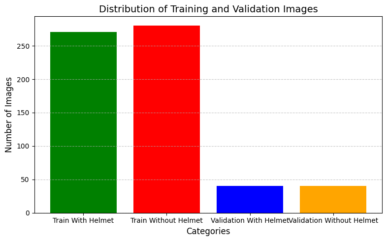

```python
plt.figure(figsize=(8, 5))
plt.bar(categories, values, color=['green', 'red', 'blue', 'orange'])  # categories = x-axis, values = heights

# Adding titles and labels
plt.title('Distribution of Training and Validation Images', fontsize=14)
plt.xlabel('Categories', fontsize=12)
plt.ylabel('Number of Images', fontsize=12)
plt.grid(axis='y', linestyle='--', alpha=0.7)

# Show the plot
plt.tight_layout()
plt.show()
```

Random images from dataset

```python
def plot_random_images(folder_path, title, num_images=5):
    # Filter only valid image extensions
    valid_ext = ('.jpg', '.jpeg', '.png', '.bmp', '.webp')
    image_files = [
        f for f in os.listdir(folder_path)
        if f.lower().endswith(valid_ext)
    ]

    if not image_files:
        print(f"[ERROR] No image files found in: {folder_path}")
        return

    if len(image_files) < num_images:
        print(f"[WARN] Only {len(image_files)} images available, adjusting num_images.")
        num_images = len(image_files)

    selected_images = random.sample(image_files, num_images)

    fig, axes = plt.subplots(1, num_images, figsize=(15, 5))
    if num_images == 1:
        axes = [axes]

    for i, image_file in enumerate(selected_images):
        image_path = os.path.join(folder_path, image_file)
        try:
            img = mpimg.imread(image_path)
            axes[i].imshow(img)
            axes[i].axis('off')
            axes[i].set_title(f'{title} #{i + 1}', fontsize=10)
        except Exception as e:
            print(f"[ERROR] Could not read {image_file}: {e}")

    plt.tight_layout()
    plt.show()
    plt.close(fig)  # Libera memoria
```

```python
# Paths to the folders
with_helmet_path_training = os.path.join(training_data_images_path, 'WorkersWithHelmet')
without_helmet_path_training = os.path.join(training_data_images_path, 'WorkersWithoutHelmet')
with_helmet_path_validation = os.path.join(validation_data_images_path, 'WorkersWithHelmet')
without_helmet_path_validation = os.path.join(validation_data_images_path, 'WorkersWithoutHelmet')
```

[figure not shown]

```python
# Plot 5 random images with helmet from training data
plot_random_images(with_helmet_path_training, 'With Helmet', num_images=5)
```

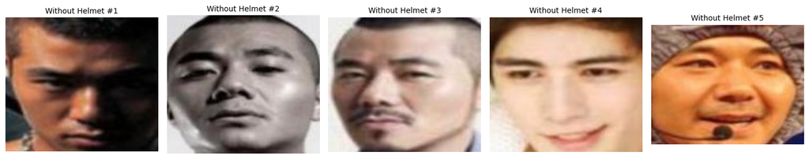

```python
# Plot 5 random images without helmet from training data
plot_random_images(without_helmet_path_training, 'Without Helmet', num_images=5)
```

## Observations — Exploratory Data Analysis

### Visual Distribution Between Classes (Critical Finding)

Sample images reveal a **significant visual asymmetry** between the two classes:

| Feature | `WorkersWithHelmet` | `WorkersWithoutHelmet` |
| --- | --- | --- |
| Framing | Full body or mid-body shot | Close-up of face / head only |
| Background context | Construction site, scaffolding, machinery | Neutral or indoor background |
| Persons per image | Frequently multiple | Single person |
| Facial resolution | Low (person further from camera) | High (face is the dominant subject) |

# **Object Detection**

```python
# Load the YOLOv5 small model — best balance of speed and accuracy for person detection
model = torch.hub.load('ultralytics/yolov5', 'yolov5s')  # yolov5s = small variant
```

```
requirements: Ultralytics requirement ['urllib3>=2.6.0 ; python_version > "3.8"'] not found, attempting AutoUpdate...
```

```
YOLOv5 🚀 2026-3-29 Python-3.11.13 torch-2.11.0 CPU

Fusing layers...
YOLOv5s summary: 213 layers, 7225885 parameters, 0 gradients, 16.4 GFLOPs
Adding AutoShape...
```

```python
def detect_and_count_persons(model, image_path, show_image=False):
    """
    Function to detect and count the number of persons in an image.
    - Displays the original image.
    - Prints the count of persons detected.
    - Shows the image with bounding boxes drawn.

    Args:
        image_path (str): Path to the input image.
    """
    # Perform inference
    results = model(image_path)

    # Extract predictions
    detections = results.xyxy[0]  # Get bounding boxes in xyxy format
    person_count = 0

    # Iterate over detections and count 'person' labels (class 0 in COCO)
    for detection in detections:
        class_id = int(detection[5])  # Class ID is in the 6th position (zero-indexed)
        if class_id == 0 and 0.30 < detection[4]:  # 'person' class in COCO
            person_count += 1

    # Print the count of persons detected
    print(f"Number of persons detected: {person_count}")

    # Display the original image
    if show_image:
      original_image = Image.open(image_path)
      plt.figure(figsize=(10, 8))
      plt.imshow(original_image)
      plt.axis('off')
      plt.title('Original Image')
      plt.show()

      # Display the image with bounding boxes
      print("Displaying image with bounding boxes:")
      results.show()  # Shows images with bounding box

    return results
```

```
Number of persons detected: 2
```

[figure not shown]

```
Displaying image with bounding boxes:
```

[figure not shown]

```python
# detect people in an image and plot the image with the corresponding bounding boxes
img_path = os.path.join(with_helmet_path_training, os.listdir(with_helmet_path_training)[1])
results = detect_and_count_persons(model, img_path, show_image=True)
```

```
Number of persons detected: 0
```

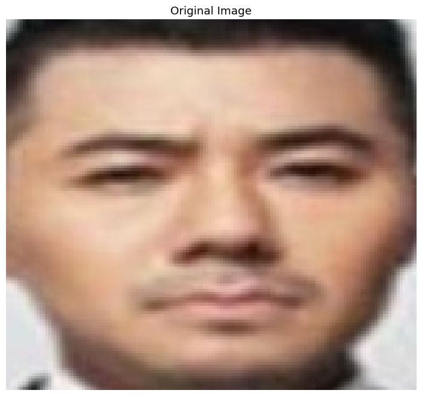

```
Displaying image with bounding boxes:
```

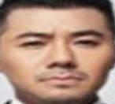

```python
img_path_2 = os.path.join(without_helmet_path_training, os.listdir(without_helmet_path_training)[1])
# NOTE: For close-up face images, YOLO may detect 0 persons — this is expected behavior.
# Those images are still used directly (as original) in dataset_generator for the WithoutHelmet class.
results_2 = detect_and_count_persons(model, img_path_2, True)
```

```python
def crop_person_images(image_path, results, confidence_threshold=0.30):
    """
    Crops images of persons detected by YOLOv5.
    Only crops persons with a confidence score greater than the threshold.

    Args:
        image_path (str): Path to the input image.
        results (YOLO result object): The result object from YOLO inference.
        confidence_threshold (float): Minimum confidence value for cropping persons. Default is 0.80.

    Returns:
        List of PIL Image: List of cropped images of persons detected.
    """
    # Open the original image
    original_image = Image.open(image_path)

    # Extract predictions (xyxy format: [x1, y1, x2, y2, confidence, class_id])
    detections = results.xyxy[0]
    cropped_images = []

    # Iterate over detections and crop images for 'person' class with high confidence
    for detection in detections:
        x1, y1, x2, y2, confidence, class_id = detection.tolist()
        class_id = int(class_id)

        if class_id == 0 and confidence > confidence_threshold:
            # Crop the image based on the bounding box coordinates
            cropped_image = original_image.crop((x1, y1, x2, y2))
            cropped_images.append(cropped_image)

    return cropped_images
```

# **Dataset Creation for Image Classification**

1. For the helmet detection task, we begin by storing the cropped images of individuals, which are extracted from the original image using the YOLO algorithm. Along with each cropped image, we also store the corresponding label indicating whether the person is wearing a helmet or not. This label serves as the ground truth for training the model.
2. To ensure consistency in the dataset, we preprocess the cropped images by resizing them to the same dimensions, typically the input size required by the model (e.g., 224x224 for ResNet) and rescaling it by dividing the pixel values by 255. This step ensures that all input images have uniform size, which is crucial for feeding them into the neural network.

**Design Decision — Asymmetric YOLO usage:**

- `WithHelmet` images → YOLO crops detected persons (label=1). Multiple crops per image are possible.
- `WithoutHelmet` images → Original image used directly (label=0). YOLO is intentionally skipped because many of these images are close-up face shots where YOLO person detection fails (YOLO is optimized for full-body bounding boxes). Using the original image ensures no close-up data is lost.

```python
# Creating the dataset from the images
def dataset_generator(with_helmet_path, without_helmet_path):

  dataset = []

  all_helmet_images_name = os.listdir(with_helmet_path)
  all_non_helmet_images_name = os.listdir(without_helmet_path)

  for helmet_image_name in all_helmet_images_name:
    image_path = os.path.join(with_helmet_path, helmet_image_name)
    results = detect_and_count_persons(model, image_path=image_path)
    # Pass the YOLO detection results to crop individual persons from the image
    cropped_images = crop_person_images(image_path, results)

    for croped_image in cropped_images:
      dataset.append([croped_image, 1])

  for non_helmet_image_name in all_non_helmet_images_name:
    img_path = os.path.join(without_helmet_path, non_helmet_image_name)
    original_image = Image.open(img_path)
    # WithoutHelmet: use original image directly — intentional.
    # Close-up face shots are not detected by YOLO as 'persons'.
    # Skipping YOLO here ensures all without-helmet samples are retained.
    dataset.append([original_image, 0])

  return dataset
```

```python
train_dataset = dataset_generator(with_helmet_path_training, without_helmet_path_training)
validation_dataset = dataset_generator(with_helmet_path_validation, without_helmet_path_validation)
```

[output not shown]

[output cut: 256 more lines]

[output not shown]

```python
# A function to preprocess the images

def transform_image(image):
    img = image.convert('RGB')       # Ensure 3-channel RGB (handles grayscale/RGBA edge cases)
    img = img.resize((224, 224))     # Resize to ResNet50 input dimensions

    # Convert image to numpy array
    img = np.array(img) / 255.0      # Normalize pixel values to [0, 1]
    return img
```

```python
def process_images_and_labels(data):
    images = []
    labels = []

    for image, label in data:
        img = transform_image(image)
        images.append(img)
        labels.append(label)

    images = np.array(images)
    labels = np.array(labels)

    return images, labels
```

```python
train_processed_images, train_labels = process_images_and_labels(train_dataset)
validation_processed_images, validation_labels = process_images_and_labels(validation_dataset)
```

```python
# Split training dataset into train and test — stratify preserves class ratio in both splits
X_train, X_test, y_train, y_test = train_test_split(
    train_processed_images,
    train_labels,
    test_size=0.1,
    random_state=42,
    stratify=train_labels   # stratify on labels to maintain class distribution
)
X_val, y_val = validation_processed_images, validation_labels

print(X_train.shape, y_train.shape)
print(X_val.shape, y_val.shape)
print(X_test.shape, y_test.shape)
```

```
(546, 224, 224, 3) (546,)
(85, 224, 224, 3) (85,)
(61, 224, 224, 3) (61,)
```

# **Image Classification**

In this step, we will load a pretrained ResNet50 model that has already been trained on a large and diverse dataset, such as ImageNet.

- ResNet50 is a deep convolutional neural network known for its residual connections, which allow it to efficiently train very deep networks without the problem of vanishing gradients.
- This architecture is widely used for tasks such as image classification, and it can be fine-tuned to recognize specific objects, like helmets, in our case.

## Utility Function

```python
# defining a function to compute different metrics to check performance of a classification model built using statsmodels
from sklearn.metrics import confusion_matrix, f1_score, accuracy_score, recall_score, precision_score, classification_report
def model_performance_classification(model, predictors, target):
    """
    Function to compute different metrics to check classification model performance

    model: classifier
    predictors: independent variables
    target: dependent variable
    """

    # checking which probabilities are greater than threshold
    predictions = np.round(model.predict(predictors)).flatten()

    # Calculate precision and recall
    accuracy = accuracy_score(target, predictions)
    precision = precision_score(target, predictions)
    recall = recall_score(target, predictions)
    f1 = f1_score(target, predictions)  # to compute F1-score

    # creating a dataframe of metrics
    df_perf = pd.DataFrame(
        {"Accuracy": accuracy, "Recall": recall, "Precision": precision, "F1 Score": f1,},
        index=[0],
    )

    return df_perf
```

## Model 1 ( Base model + output layer)

```python
# Load the Pretrained ResNet model
base_model = tf.keras.applications.ResNet50(weights='imagenet', include_top=False, input_shape=(224, 224, 3))
for layer in base_model.layers[:-10]:
    layer.trainable = False  # Freeze all layers except the last 10 (allow fine-tuning of top layers)
```

```python
model = tf.keras.models.Sequential([
    base_model,
    tf.keras.layers.GlobalAveragePooling2D(),
    tf.keras.layers.Flatten(),
    tf.keras.layers.Dense(1, activation='sigmoid')  # Binary classification: 1 output neuron with sigmoid
])

# Compile the model
model.compile(
    optimizer=tf.keras.optimizers.Adam(learning_rate=0.001),  # Adam optimizer, lr=0.001
    loss='binary_crossentropy',
    metrics=['accuracy']
)
```

```python
train_datagen = ImageDataGenerator()
```

```python
#Train the model
epochs = 10
# Batch size
batch_size = 32

history_model_1 = model.fit(train_datagen.flow(X_train, y_train,
                                       shuffle=False),
                    epochs=epochs,
                    batch_size=batch_size,
                    validation_data=(X_val, y_val),
                    verbose=1)
```

```
18/18 ━━━━━━━━━━━━━━━━━━━━ 9s 321ms/step - accuracy: 0.8736 - loss: 0.2724 - val_accuracy: 0.5294 - val_loss: 20.4329
18/18 ━━━━━━━━━━━━━━━━━━━━ 2s 122ms/step - accuracy: 0.9396 - loss: 0.1501 - val_accuracy: 0.5294 - val_loss: 18.2573
18/18 ━━━━━━━━━━━━━━━━━━━━ 2s 121ms/step - accuracy: 0.9579 - loss: 0.1145 - val_accuracy: 0.5294 - val_loss: 10.2510
18/18 ━━━━━━━━━━━━━━━━━━━━ 2s 122ms/step - accuracy: 0.9780 - loss: 0.0711 - val_accuracy: 0.8235 - val_loss: 0.6067
18/18 ━━━━━━━━━━━━━━━━━━━━ 2s 121ms/step - accuracy: 0.9780 - loss: 0.0578 - val_accuracy: 0.8824 - val_loss: 0.3422
18/18 ━━━━━━━━━━━━━━━━━━━━ 2s 121ms/step - accuracy: 0.9744 - loss: 0.0555 - val_accuracy: 0.8471 - val_loss: 0.4131
18/18 ━━━━━━━━━━━━━━━━━━━━ 2s 121ms/step - accuracy: 0.9853 - loss: 0.0383 - val_accuracy: 0.4941 - val_loss: 2.2070
18/18 ━━━━━━━━━━━━━━━━━━━━ 2s 121ms/step - accuracy: 0.9927 - loss: 0.0218 - val_accuracy: 0.7294 - val_loss: 0.5760
18/18 ━━━━━━━━━━━━━━━━━━━━ 2s 121ms/step - accuracy: 0.9927 - loss: 0.0258 - val_accuracy: 0.5647 - val_loss: 1.1340
18/18 ━━━━━━━━━━━━━━━━━━━━ 2s 122ms/step - accuracy: 0.9945 - loss: 0.0214 - val_accuracy: 0.5412 - val_loss: 2.3414
```

Evaluating Model performance on training and validation data.

```python
model_perf_df_val = model_performance_classification(model, X_val, y_val)
model_perf_df_val
```

```
3/3 ━━━━━━━━━━━━━━━━━━━━ 3s 780ms/step
```

|  | Accuracy | Recall | Precision | F1 Score |
| --- | --- | --- | --- | --- |
| 0 | 0.541176 | 1.0 | 0.535714 | 0.697674 |

```python
model_perf_df_train = model_performance_classification(model, X_train, y_train)
model_perf_df_train
```

```
18/18 ━━━━━━━━━━━━━━━━━━━━ 2s 114ms/step
```

|  | Accuracy | Recall | Precision | F1 Score |
| --- | --- | --- | --- | --- |
| 0 | 0.543956 | 1.0 | 0.541436 | 0.702509 |

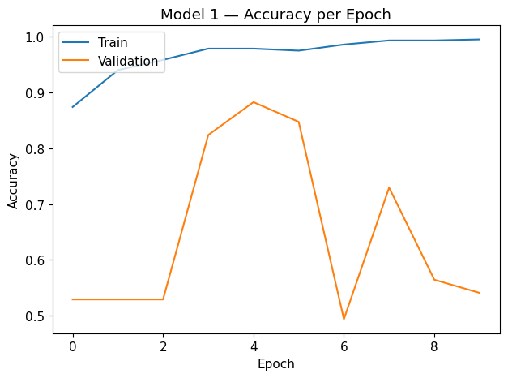

```python
plt.plot(history_model_1.history['accuracy'], label='Train')
plt.plot(history_model_1.history['val_accuracy'], label='Validation')
plt.title('Model 1 — Accuracy per Epoch')
plt.ylabel('Accuracy')
plt.xlabel('Epoch')
plt.legend(loc='upper left')
plt.tight_layout()
plt.show()
```

## Observations — Model 1 (Base ResNet50 + Output Layer)

### Performance Metrics

| Set | Accuracy | Recall | Precision | F1 |
| --- | --- | --- | --- | --- |
| Validation | 0.541 | 1.0 | 0.536 | 0.698 |
| Train | 0.544 | 1.0 | 0.541 | 0.702 |

- **Recall = 1.0 with Precision ~0.54** on both sets indicates the model is predicting **class 1 (With Helmet) for every sample** — it has collapsed to a trivial majority-class predictor rather than learning to discriminate.
- An F1 of ~0.70 in this context is misleading — it is inflated by perfect Recall at the cost of near-random Precision.

### Root Cause

- The model architecture (ResNet50 frozen base + single Dense output layer) provides **insufficient capacity** for fine-tuning on a small, visually asymmetric dataset.
- The absence of regularization (no Dropout, no data augmentation) allows the unfrozen top 10 layers to overfit rapidly.
- The **visual distribution mismatch** between classes (full-body vs. close-up) likely contributes to the instability in validation accuracy across epochs.

### Conclusion

Model 1 is not viable for production use. The results establish a performance **baseline to improve upon** in subsequent models through the addition of hidden layers, Dropout regularization, and data augmentation.

# **Image Classification Performance Improvement and Final Model Selection**

## Model 2: (Base model + FFN)

```python
base_model = tf.keras.applications.ResNet50(weights='imagenet', include_top=False, input_shape=(224, 224, 3))
for layer in base_model.layers[:-10]:
    layer.trainable = False  # Freeze all layers except the last 10
```

```python
model_FFN = tf.keras.models.Sequential([
    base_model,
    tf.keras.layers.GlobalAveragePooling2D(),
    tf.keras.layers.Flatten(),
    tf.keras.layers.Dense(256, activation='relu'),  # Hidden layer 1: 256 neurons
    tf.keras.layers.Dense(128, activation='relu'),  # Hidden layer 2: 128 neurons
    tf.keras.layers.Dense(1, activation='sigmoid')
])


model_FFN.compile(
    optimizer=tf.keras.optimizers.Adam(learning_rate=0.001),  # Adam, lr=0.001
    loss='binary_crossentropy',
    metrics=['accuracy']
)
```

```python
epochs = 10
# Batch size
batch_size = 32

history_model_2 = model_FFN.fit(train_datagen.flow(X_train, y_train,
                                       batch_size=batch_size,
                                       seed=42,
                                       shuffle=False),
                    epochs=epochs,
                    validation_data=(X_val, y_val),
                    verbose=1)
```

```
18/18 ━━━━━━━━━━━━━━━━━━━━ 10s 337ms/step - accuracy: 0.7967 - loss: 0.4486 - val_accuracy: 0.5294 - val_loss: 39.0943
18/18 ━━━━━━━━━━━━━━━━━━━━ 2s 125ms/step - accuracy: 0.9286 - loss: 0.1932 - val_accuracy: 0.5294 - val_loss: 31.7864
18/18 ━━━━━━━━━━━━━━━━━━━━ 2s 126ms/step - accuracy: 0.9652 - loss: 0.1060 - val_accuracy: 0.9529 - val_loss: 0.2909
18/18 ━━━━━━━━━━━━━━━━━━━━ 2s 124ms/step - accuracy: 0.9762 - loss: 0.0854 - val_accuracy: 0.5529 - val_loss: 3.8086
18/18 ━━━━━━━━━━━━━━━━━━━━ 2s 124ms/step - accuracy: 0.9707 - loss: 0.0710 - val_accuracy: 0.4941 - val_loss: 8.0008
18/18 ━━━━━━━━━━━━━━━━━━━━ 2s 125ms/step - accuracy: 0.9670 - loss: 0.0758 - val_accuracy: 0.6941 - val_loss: 1.8924
18/18 ━━━━━━━━━━━━━━━━━━━━ 2s 124ms/step - accuracy: 0.9872 - loss: 0.0503 - val_accuracy: 0.9529 - val_loss: 0.2125
18/18 ━━━━━━━━━━━━━━━━━━━━ 2s 124ms/step - accuracy: 0.9762 - loss: 0.0647 - val_accuracy: 0.7647 - val_loss: 1.6047
18/18 ━━━━━━━━━━━━━━━━━━━━ 2s 124ms/step - accuracy: 0.9780 - loss: 0.0454 - val_accuracy: 0.8824 - val_loss: 0.8015
18/18 ━━━━━━━━━━━━━━━━━━━━ 2s 124ms/step - accuracy: 0.9744 - loss: 0.0740 - val_accuracy: 0.8118 - val_loss: 0.9594
```

```python
model_FFN_perf_df_val = model_performance_classification(model_FFN, X_val, y_val)
model_FFN_perf_df_val
```

```
3/3 ━━━━━━━━━━━━━━━━━━━━ 3s 908ms/step
```

|  | Accuracy | Recall | Precision | F1 Score |
| --- | --- | --- | --- | --- |
| 0 | 0.811765 | 1.0 | 0.737705 | 0.849057 |

```python
model_FFN_perf_df_train = model_performance_classification(model_FFN, X_train, y_train)
model_FFN_perf_df_train
```

```
18/18 ━━━━━━━━━━━━━━━━━━━━ 2s 117ms/step
```

|  | Accuracy | Recall | Precision | F1 Score |
| --- | --- | --- | --- | --- |
| 0 | 0.842491 | 1.0 | 0.773684 | 0.872404 |

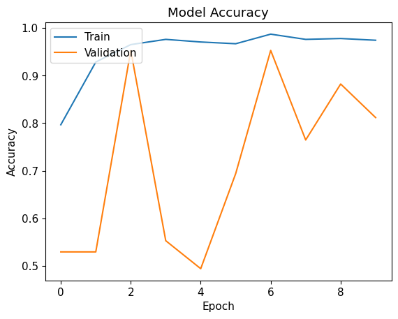

```python
plt.plot(history_model_2.history['accuracy'])
plt.plot(history_model_2.history['val_accuracy'])
plt.title('Model Accuracy')
plt.ylabel('Accuracy')
plt.xlabel('Epoch')
plt.legend(['Train', 'Validation'], loc='upper left')
plt.show()
```

## Observations — Model 2 (ResNet50 + FFN)

### Training Behavior

- Training accuracy reached **97.44%** by epoch 10, consistent with Model 1.
- Validation accuracy showed improvement over Model 1 but remains **highly unstable**, oscillating between **0.49 and 0.95** with no convergence — spikes at epoch 3 (0.95) and epoch 7 (0.95) followed by sharp drops indicate the model is sensitive to batch composition rather than having learned stable representations.
- Validation loss mirrors this instability (0.29 → 39.09 → 0.21 → 0.96), confirming the model has not generalized reliably.

### Performance Metrics

| Set | Accuracy | Recall | Precision | F1 |
| --- | --- | --- | --- | --- |
| Validation | 0.812 | 1.0 | 0.738 | 0.849 |
| Train | 0.842 | 1.0 | 0.774 | 0.872 |

- **Significant improvement over Model 1**: Precision jumped from ~0.54 to ~0.74 on validation, and F1 from 0.698 to 0.849.
- **Recall = 1.0 persists** on both sets — the model still predicts class 1 (With Helmet) with high frequency, though Precision improvement indicates it is beginning to discriminate rather than blindly predicting the majority class.
- The train/val accuracy gap (~0.97 vs ~0.81) confirms **overfitting is still present**, reduced but not controlled.

### Compared to Model 1

| Metric | Model 1 Val | Model 2 Val | Δ |
| --- | --- | --- | --- |
| Accuracy | 0.541 | 0.812 | **+0.271** |
| Precision | 0.536 | 0.738 | **+0.202** |
| F1 Score | 0.698 | 0.849 | **+0.151** |

### Root Cause of Remaining Instability

- The addition of two hidden layers (256 → 128 → 1) increased model capacity and improved discrimination, but **no regularization** (no Dropout, no augmentation) was applied — the model still overfits rapidly on the small training set.
- The erratic validation curve suggests high sensitivity to the specific samples in each validation batch, likely exacerbated by the visual distribution mismatch between classes identified in EDA.

### Conclusion

Model 2 demonstrates that adding hidden layers provides a meaningful improvement in discriminative capacity. However, the lack of regularization results in an unstable validation curve and persistent overfitting.

## Model 3 (Base model + FFN + Data Augmentation) with dropout

Lets add a dropout and data augmentation. We will also decrease the learning rate so that we can reach a global minimnum.

```python
base_model = tf.keras.applications.ResNet50(weights='imagenet', include_top=False, input_shape=(224, 224, 3))
for layer in base_model.layers[:-10]:
    layer.trainable = False  # Freeze all layers except the last 10
```

```python
model_FFN_DA = tf.keras.models.Sequential([
    base_model,
    tf.keras.layers.GlobalAveragePooling2D(),
    tf.keras.layers.Flatten(),
    tf.keras.layers.Dense(128, activation='relu'),
    tf.keras.layers.Dropout(0.5),   # Drop 50% of neurons to reduce overfitting
    tf.keras.layers.Dense(64, activation='relu'),
    tf.keras.layers.Dense(1, activation='sigmoid')
])


model_FFN_DA.compile(
    optimizer=tf.keras.optimizers.Adam(learning_rate=0.0001),  # Reduced lr=0.0001 for stable convergence
    loss='binary_crossentropy',
    metrics=['accuracy']
)
```

```python
# Applying data augmentation
train_datagen = ImageDataGenerator(
    rotation_range=20,           # Rotate images up to 20 degrees
    fill_mode='nearest',
    width_shift_range=0.2,       # Shift width by 20%
    height_shift_range=0.2,      # Shift height by 20%
    shear_range=0.3,
    zoom_range=0.4
)
```

```python
epochs = 20
# Batch size
batch_size = 32

history_model_3 = model_FFN_DA.fit(train_datagen.flow(X_train, y_train,
                                       batch_size=batch_size,
                                       seed=42,
                                       shuffle=False),
                    epochs=epochs,
                    validation_data=(X_val, y_val),
                    verbose=1)
```

```
18/18 ━━━━━━━━━━━━━━━━━━━━ 10s 331ms/step - accuracy: 0.6813 - loss: 0.6144 - val_accuracy: 0.5294 - val_loss: 1.0292
18/18 ━━━━━━━━━━━━━━━━━━━━ 2s 130ms/step - accuracy: 0.8462 - loss: 0.3722 - val_accuracy: 0.5294 - val_loss: 0.9875
18/18 ━━━━━━━━━━━━━━━━━━━━ 2s 128ms/step - accuracy: 0.8608 - loss: 0.3245 - val_accuracy: 0.5294 - val_loss: 0.7618
18/18 ━━━━━━━━━━━━━━━━━━━━ 2s 128ms/step - accuracy: 0.8773 - loss: 0.2664 - val_accuracy: 0.5294 - val_loss: 1.1056
18/18 ━━━━━━━━━━━━━━━━━━━━ 2s 128ms/step - accuracy: 0.8974 - loss: 0.2420 - val_accuracy: 0.5294 - val_loss: 1.1781
18/18 ━━━━━━━━━━━━━━━━━━━━ 2s 127ms/step - accuracy: 0.8993 - loss: 0.2590 - val_accuracy: 0.5294 - val_loss: 0.9329
18/18 ━━━━━━━━━━━━━━━━━━━━ 2s 129ms/step - accuracy: 0.9121 - loss: 0.2139 - val_accuracy: 0.5294 - val_loss: 0.8157
18/18 ━━━━━━━━━━━━━━━━━━━━ 2s 128ms/step - accuracy: 0.9176 - loss: 0.1958 - val_accuracy: 0.5294 - val_loss: 1.0841
18/18 ━━━━━━━━━━━━━━━━━━━━ 2s 128ms/step - accuracy: 0.9231 - loss: 0.2173 - val_accuracy: 0.5294 - val_loss: 1.0222
18/18 ━━━━━━━━━━━━━━━━━━━━ 2s 128ms/step - accuracy: 0.9212 - loss: 0.1899 - val_accuracy: 0.5294 - val_loss: 0.6155
18/18 ━━━━━━━━━━━━━━━━━━━━ 2s 127ms/step - accuracy: 0.9011 - loss: 0.2193 - val_accuracy: 0.5647 - val_loss: 0.5605
18/18 ━━━━━━━━━━━━━━━━━━━━ 2s 124ms/step - accuracy: 0.9359 - loss: 0.1812 - val_accuracy: 0.5294 - val_loss: 1.2235
18/18 ━━━━━━━━━━━━━━━━━━━━ 2s 128ms/step - accuracy: 0.9048 - loss: 0.2366 - val_accuracy: 0.9059 - val_loss: 0.2587
18/18 ━━━━━━━━━━━━━━━━━━━━ 2s 128ms/step - accuracy: 0.9121 - loss: 0.2174 - val_accuracy: 0.9647 - val_loss: 0.1836
18/18 ━━━━━━━━━━━━━━━━━━━━ 2s 133ms/step - accuracy: 0.9304 - loss: 0.1977 - val_accuracy: 0.7647 - val_loss: 0.4899
18/18 ━━━━━━━━━━━━━━━━━━━━ 2s 128ms/step - accuracy: 0.9249 - loss: 0.1897 - val_accuracy: 0.9765 - val_loss: 0.1829
18/18 ━━━━━━━━━━━━━━━━━━━━ 2s 128ms/step - accuracy: 0.9414 - loss: 0.1600 - val_accuracy: 0.9412 - val_loss: 0.2016
18/18 ━━━━━━━━━━━━━━━━━━━━ 2s 130ms/step - accuracy: 0.9359 - loss: 0.1718 - val_accuracy: 0.9765 - val_loss: 0.2135
18/18 ━━━━━━━━━━━━━━━━━━━━ 2s 127ms/step - accuracy: 0.9396 - loss: 0.2070 - val_accuracy: 0.9412 - val_loss: 0.1785
18/18 ━━━━━━━━━━━━━━━━━━━━ 2s 133ms/step - accuracy: 0.9322 - loss: 0.1692 - val_accuracy: 0.9529 - val_loss: 0.1595
```

```python
model_FFN_DA_perf_df_val = model_performance_classification(model_FFN_DA, X_val, y_val)
model_FFN_DA_perf_df_val
```

```
3/3 ━━━━━━━━━━━━━━━━━━━━ 3s 877ms/step
```

|  | Accuracy | Recall | Precision | F1 Score |
| --- | --- | --- | --- | --- |
| 0 | 0.952941 | 0.933333 | 0.976744 | 0.954545 |

```python
model_FFN_DA_perf_df_train = model_performance_classification(model_FFN_DA, X_train, y_train)
model_FFN_DA_perf_df_train
```

```
18/18 ━━━━━━━━━━━━━━━━━━━━ 2s 114ms/step
```

|  | Accuracy | Recall | Precision | F1 Score |
| --- | --- | --- | --- | --- |
| 0 | 0.912088 | 0.836735 | 1.0 | 0.911111 |

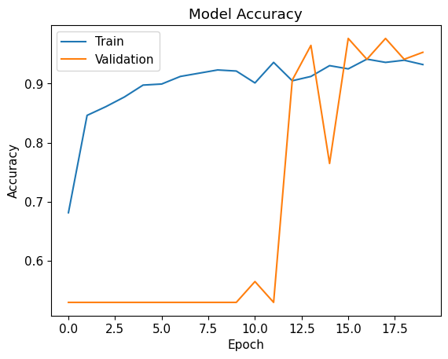

```python
plt.plot(history_model_3.history['accuracy'])
plt.plot(history_model_3.history['val_accuracy'])
plt.title('Model Accuracy')
plt.ylabel('Accuracy')
plt.xlabel('Epoch')
plt.legend(['Train', 'Validation'], loc='upper left')
plt.show()
```

## Observations — Model 3 (ResNet50 + FFN + Dropout + Data Augmentation)

### Performance Metrics

| Set | Accuracy | Recall | Precision | F1 |
| --- | --- | --- | --- | --- |
| Validation | 0.953 | 0.933 | 0.977 | 0.955 |
| Train | 0.912 | 0.837 | 1.0 | 0.911 |

### Compared to Previous Models

| Metric | Model 1 Val | Model 2 Val | Model 3 Val |
| --- | --- | --- | --- |
| Accuracy | 0.541 | 0.812 | **0.953** |
| Recall | 1.0 | 1.0 | **0.933** |
| Precision | 0.536 | 0.738 | **0.977** |
| F1 Score | 0.698 | 0.849 | **0.955** |

### Key Drivers of Improvement

- **Dropout (0.5)** prevented co-adaptation of neurons, forcing the network to learn redundant representations robust to feature dropout.
- **Reduced learning rate (0.0001)** enabled finer gradient updates, critical for fine-tuning the top ResNet50 layers without overshooting the loss minimum.
- **Data augmentation** (rotation, shift, zoom, shear) diversified the training distribution, partially compensating for the visual asymmetry between classes identified in EDA.

## Model 4 (Using a different optimizer and reducing batch size)

We will be using the same model architecture as above, but this time we will use Stochastic Gradient Descent optimizer with a larger learning rate to compile our model. We will decrease our batch size so that we can have faster convergences and better generalization.

```python
base_model = tf.keras.applications.ResNet50(weights='imagenet', include_top=False, input_shape=(224, 224, 3))
for layer in base_model.layers[:-10]:
    layer.trainable = False  # Freeze all layers except the last 10
```

```python
model_FFN_DA_2 = tf.keras.models.Sequential([
    base_model,
    tf.keras.layers.GlobalAveragePooling2D(),
    tf.keras.layers.Flatten(),
    tf.keras.layers.Dense(128, activation='relu'),
    tf.keras.layers.Dropout(0.5),   # Drop 50% of neurons
    tf.keras.layers.Dense(64, activation='relu'),
    tf.keras.layers.Dense(1, activation='sigmoid')
])

# BUG FIX: original had misplaced closing parenthesis that excluded loss and metrics from compile()
model_FFN_DA_2.compile(
    optimizer=tf.keras.optimizers.SGD(learning_rate=0.001),  # SGD with momentum default
    loss='binary_crossentropy',
    metrics=['accuracy']
)
```

```python
# Applying data augmentation
train_datagen = ImageDataGenerator(
    rotation_range=20,
    fill_mode='nearest',
    width_shift_range=0.2,
    height_shift_range=0.2,
    shear_range=0.3,
    zoom_range=0.4
)

epochs = 20

batch_size = 16  # Reduced from 32 — smaller batches = noisier gradients = better generalization with SGD

history_model_4 = model_FFN_DA_2.fit(train_datagen.flow(X_train, y_train,
                                       batch_size=batch_size,
                                       seed=42,
                                       shuffle=True,
                                       ),
                    epochs=epochs,
                    validation_data=(X_val, y_val),
                    verbose=1)
```

```
35/35 ━━━━━━━━━━━━━━━━━━━━ 8s 146ms/step - accuracy: 0.5696 - loss: 0.7900 - val_accuracy: 0.6235 - val_loss: 0.6781
35/35 ━━━━━━━━━━━━━━━━━━━━ 2s 67ms/step - accuracy: 0.6447 - loss: 0.6517 - val_accuracy: 0.7647 - val_loss: 0.6675
35/35 ━━━━━━━━━━━━━━━━━━━━ 2s 65ms/step - accuracy: 0.6850 - loss: 0.5724 - val_accuracy: 0.8235 - val_loss: 0.6504
35/35 ━━━━━━━━━━━━━━━━━━━━ 2s 66ms/step - accuracy: 0.7289 - loss: 0.5087 - val_accuracy: 0.5294 - val_loss: 0.6603
35/35 ━━━━━━━━━━━━━━━━━━━━ 2s 65ms/step - accuracy: 0.7473 - loss: 0.4880 - val_accuracy: 0.5294 - val_loss: 0.6608
35/35 ━━━━━━━━━━━━━━━━━━━━ 2s 67ms/step - accuracy: 0.7747 - loss: 0.4513 - val_accuracy: 0.5294 - val_loss: 0.6312
35/35 ━━━━━━━━━━━━━━━━━━━━ 2s 66ms/step - accuracy: 0.7930 - loss: 0.4435 - val_accuracy: 0.5294 - val_loss: 0.6112
35/35 ━━━━━━━━━━━━━━━━━━━━ 2s 66ms/step - accuracy: 0.7912 - loss: 0.4355 - val_accuracy: 0.5294 - val_loss: 0.5256
35/35 ━━━━━━━━━━━━━━━━━━━━ 2s 65ms/step - accuracy: 0.7949 - loss: 0.4321 - val_accuracy: 0.5294 - val_loss: 0.6416
35/35 ━━━━━━━━━━━━━━━━━━━━ 2s 65ms/step - accuracy: 0.8095 - loss: 0.4195 - val_accuracy: 0.5294 - val_loss: 0.5195
35/35 ━━━━━━━━━━━━━━━━━━━━ 2s 65ms/step - accuracy: 0.8004 - loss: 0.4299 - val_accuracy: 0.9176 - val_loss: 0.3656
35/35 ━━━━━━━━━━━━━━━━━━━━ 2s 66ms/step - accuracy: 0.8242 - loss: 0.3855 - val_accuracy: 0.9294 - val_loss: 0.3371
35/35 ━━━━━━━━━━━━━━━━━━━━ 2s 66ms/step - accuracy: 0.8077 - loss: 0.3959 - val_accuracy: 0.9647 - val_loss: 0.2904
35/35 ━━━━━━━━━━━━━━━━━━━━ 2s 66ms/step - accuracy: 0.8059 - loss: 0.4055 - val_accuracy: 0.9294 - val_loss: 0.2720
35/35 ━━━━━━━━━━━━━━━━━━━━ 2s 66ms/step - accuracy: 0.8553 - loss: 0.3597 - val_accuracy: 0.9529 - val_loss: 0.2784
35/35 ━━━━━━━━━━━━━━━━━━━━ 2s 65ms/step - accuracy: 0.8498 - loss: 0.3582 - val_accuracy: 0.9647 - val_loss: 0.2261
35/35 ━━━━━━━━━━━━━━━━━━━━ 2s 66ms/step - accuracy: 0.8590 - loss: 0.3553 - val_accuracy: 0.9647 - val_loss: 0.2203
35/35 ━━━━━━━━━━━━━━━━━━━━ 2s 66ms/step - accuracy: 0.8443 - loss: 0.3458 - val_accuracy: 0.9647 - val_loss: 0.1961
35/35 ━━━━━━━━━━━━━━━━━━━━ 2s 66ms/step - accuracy: 0.8352 - loss: 0.3554 - val_accuracy: 0.9529 - val_loss: 0.1881
35/35 ━━━━━━━━━━━━━━━━━━━━ 2s 66ms/step - accuracy: 0.8681 - loss: 0.3147 - val_accuracy: 0.9059 - val_loss: 0.2862
```

```python
model_FFN_DA_2_perf_df_val = model_performance_classification(model_FFN_DA_2, X_val, y_val)
model_FFN_DA_2_perf_df_val
```

```
3/3 ━━━━━━━━━━━━━━━━━━━━ 4s 1s/step
```

|  | Accuracy | Recall | Precision | F1 Score |
| --- | --- | --- | --- | --- |
| 0 | 0.905882 | 1.0 | 0.849057 | 0.918367 |

```python
model_FFN_DA_2_perf_df_train = model_performance_classification(model_FFN_DA_2, X_train, y_train)
model_FFN_DA_2_perf_df_train
```

```
18/18 ━━━━━━━━━━━━━━━━━━━━ 2s 118ms/step
```

|  | Accuracy | Recall | Precision | F1 Score |
| --- | --- | --- | --- | --- |
| 0 | 0.950549 | 0.996599 | 0.918495 | 0.955954 |

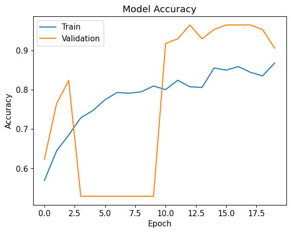

```python
plt.plot(history_model_4.history['accuracy'])
plt.plot(history_model_4.history['val_accuracy'])
plt.title('Model Accuracy')
plt.ylabel('Accuracy')
plt.xlabel('Epoch')
plt.legend(['Train', 'Validation'], loc='upper left')
plt.show()
```

## Observations — Model 4 (ResNet50 + FFN + Dropout + Data Augmentation + SGD)

### Performance Metrics

| Set | Accuracy | Recall | Precision | F1 |
| --- | --- | --- | --- | --- |
| Validation | 0.906 | 1.0 | 0.849 | 0.918 |
| Train | 0.951 | 0.997 | 0.918 | 0.956 |

- **Recall = 1.0 on validation** reappears — unlike Model 3 (Recall 0.933), Model 4 is again predicting class 1 more aggressively, suggesting SGD with this configuration has not fully resolved the class discrimination issue.
- Precision on validation (0.849) is lower than Model 3 (0.977), confirming more False Positives — the model is less conservative when predicting "With Helmet".

### Full Model Comparison

[output not shown]

### Why Model 3 Outperforms Model 4

- **Adam vs SGD**: Adam's adaptive learning rates per parameter provide smoother convergence on small datasets. SGD with a fixed learning rate (0.001) requires more epochs and careful tuning to reach the same minimum.
- **Batch size 16 vs 32**: smaller batches increase gradient noise, which can help escape local minima but also slows stable convergence and inflates validation variance in the late epochs.
- Model 4's declining val_accuracy in the final epochs (0.9647 → 0.9059) suggests it would benefit from early stopping or learning rate decay, neither of which was applied.

## Model Performance Comparison and Final Model Selection

```python
models_train_comp_df = pd.concat(
    [
        model_perf_df_train.T,
        model_FFN_perf_df_train.T,
        model_FFN_DA_perf_df_train.T,
        model_FFN_DA_2_perf_df_train.T,


    ],
    axis=1,
)
models_train_comp_df.columns = [
    "Model 1: Simple",
    "Model 2: FFN",
    "Model 3: DA",
    'Model 4: SGD'
]

models_val_comp_df = pd.concat(
    [
        model_perf_df_val.T,
        model_FFN_perf_df_val.T,
        model_FFN_DA_perf_df_val.T,
        model_FFN_DA_2_perf_df_val.T

    ],
    axis=1,
)
models_val_comp_df.columns = [
    "Model 1: Simple",
    "Model 2: FFN",
    "Model 3: DA",
    'Model 4: SGD'
]
```

```python
print('PERFORMANCE OF MODELS ON THE TRAINING SET')
models_train_comp_df
```

```
PERFORMANCE OF MODELS ON THE TRAINING SET
```

|  | Model 1: Simple | Model 2: FFN | Model 3: DA | Model 4: SGD |
| --- | --- | --- | --- | --- |
| Accuracy | 0.543956 | 0.842491 | 0.912088 | 0.950549 |
| Recall | 1.000000 | 1.000000 | 0.836735 | 0.996599 |
| Precision | 0.541436 | 0.773684 | 1.000000 | 0.918495 |
| F1 Score | 0.702509 | 0.872404 | 0.911111 | 0.955954 |

```python
print('PERFORMANCE OF MODELS ON VALIDATION SET')
models_val_comp_df
```

```
PERFORMANCE OF MODELS ON VALIDATION SET
```

|  | Model 1: Simple | Model 2: FFN | Model 3: DA | Model 4: SGD |
| --- | --- | --- | --- | --- |
| Accuracy | 0.541176 | 0.811765 | 0.952941 | 0.905882 |
| Recall | 1.000000 | 1.000000 | 0.933333 | 1.000000 |
| Precision | 0.535714 | 0.737705 | 0.976744 | 0.849057 |
| F1 Score | 0.697674 | 0.849057 | 0.954545 | 0.918367 |

## Observations — Model Performance Comparison

### Validation Set Summary

| Metric | Model 1: Simple | Model 2: FFN | Model 3: DA | Model 4: SGD |
| --- | --- | --- | --- | --- |
| Accuracy | 0.541 | 0.812 | **0.953** | 0.906 |
| Recall | 1.000 | 1.000 | **0.933** | 1.000 |
| Precision | 0.536 | 0.738 | **0.977** | 0.849 |
| F1 Score | 0.698 | 0.849 | **0.955** | 0.918 |

### Progressive Improvement Trend

- Each architectural addition produced measurable gains on the validation set:
  - **Model 1 → Model 2** (+FFN layers): F1 +0.151, Precision +0.202 — hidden layers provided the discriminative capacity missing in the baseline.
  - **Model 2 → Model 3** (+Dropout + Augmentation + lower LR): F1 +0.106, Precision +0.239 — regularization was the single most impactful improvement, resolving the majority-class collapse seen in Models 1 and 2.
  - **Model 3 → Model 4** (+SGD + smaller batch): F1 -0.037, Precision -0.128 — the optimizer change did not improve generalization; Adam outperformed SGD on this dataset size and configuration.

### Critical Metric — Precision in a Safety Context

- For helmet compliance detection, a **False Positive** means a non-compliant worker is classified as wearing a helmet — a direct safety risk.
- Model 3 achieves **Precision = 0.977 on validation**, the highest across all models, making it the most reliable for safety-critical deployment.
- Models 1, 2, and 4 all show Recall = 1.0 on validation, indicating they still predict class 1 too aggressively — inflating Recall at the cost of Precision.

## Model Performance Check on Test Set

```python
best_model = model_FFN_DA  # Model 3 with FFN + Data Augmentation showed best validation performance based on F1/Accuracy trade-off.
```

```python
predictions = np.round(best_model.predict(X_test))
print(classification_report(y_test, predictions))
```

```
2/2 ━━━━━━━━━━━━━━━━━━━━ 1s 828ms/step
              precision    recall  f1-score   support

           0       0.85      1.00      0.92        28
           1       1.00      0.85      0.92        33

    accuracy                           0.92        61
   macro avg       0.92      0.92      0.92        61
weighted avg       0.93      0.92      0.92        61
```

Lets plot the confusion matrix to gain a deeper insight.

```
Confusion Matrix:
```

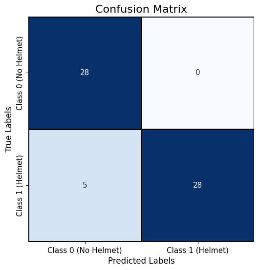

```python
#Compute Confusion Matrix
cm = confusion_matrix(y_test, predictions)

# Confusion Matrix Labels
labels = ['Class 0 (No Helmet)', 'Class 1 (Helmet)']

# Check the content of the confusion matrix to ensure it's correct
print("Confusion Matrix:")

# Plot the confusion matrix
plt.figure(figsize=(8, 6))
sns.heatmap(cm, annot=True, fmt='d', cmap='Blues',
            xticklabels=labels, yticklabels=labels,
            cbar=False, linewidths=1, linecolor='black',
            square=True)

# Add Titles and Axis Labels
plt.title('Confusion Matrix', fontsize=16)
plt.xlabel('Predicted Labels', fontsize=12)
plt.ylabel('True Labels', fontsize=12)

# # Ensure the plot window is shown
plt.show()
```

Lets plot some images of the test dataset along with the predictions.

```
1/1 - 1s - 579ms/step
1/1 - 0s - 34ms/step
1/1 - 0s - 33ms/step
1/1 - 0s - 43ms/step
1/1 - 0s - 27ms/step
```

[figure not shown]

```python
num_images = 5

# Select 5 random images from the test set
selected_images = sample = np.array(random.sample(list(X_test), num_images))

class_dict = {0: 'No Helmet Detected', 1: 'Helmet Detected'}

# Plot the images
plt.figure(figsize=(15, 5))
for i, image_file in enumerate(selected_images):
    confidence = best_model.predict(np.expand_dims(image_file, axis=0), verbose=2)
    prediction = int(np.round(confidence))
    if prediction == 0:
        confidence = (1 - confidence) * 100
    else:
        confidence = confidence[0][0] * 100
    detected_class = class_dict[prediction]
    plt.subplot(1, num_images, i + 1)  # Arrange images in 1 row
    plt.imshow(image_file)
    plt.axis('off')  # Hide axes
    plt.title(f' image #{i + 1} \nPredicted Class:{detected_class}\nConfidence:{np.round(confidence,2)}%', fontsize=10)
plt.tight_layout()
plt.show()
```

## Observations — Model Performance on Test Set

### Classification Report

| Class | Precision | Recall | F1 | Support |
| --- | --- | --- | --- | --- |
| 0 — No Helmet | 0.85 | 1.00 | 0.92 | 28 |
| 1 — Helmet | 1.00 | 0.85 | 0.92 | 33 |
| **Overall Accuracy** |  |  | **0.92** | **61** |

### Confusion Matrix Breakdown

|  | Predicted No Helmet | Predicted Helmet |
| --- | --- | --- |
| **Actual No Helmet** | 28 (TN) | 0 (FP) |
| **Actual Helmet** | 5 (FN) | 28 (TP) |

### Key Findings

- **Zero False Positives (FP = 0)**: the model never classified a non-compliant worker as wearing a helmet. In a safety-critical context this is the most important result — no undetected compliance violations on the test set.
- **5 False Negatives (FN = 5)**: 5 workers wearing helmets were classified as non-compliant. These are operationally acceptable errors — they trigger unnecessary alerts but do not represent a safety risk.
- **Precision = 1.0 on class 1 (Helmet)**: every positive prediction was correct, confirming the model's conservative and reliable behavior when flagging compliance.
- **Recall = 1.0 on class 0 (No Helmet)**: all 28 non-compliant workers were correctly identified — no safety violations went undetected.

### Generalization Assessment

- Test accuracy (0.92) is consistent with validation accuracy (0.953), confirming the model **generalizes well** to unseen data without significant degradation.
- The macro average F1 (0.92) equals the weighted average F1 (0.92), indicating **balanced performance across both classes** despite the visual distribution asymmetry identified in EDA.

### Conclusion

The final model (Model 3) achieves **92% test accuracy with zero False Positives**, making it suitable for production deployment as a first-pass automated compliance screening tool. The 5 False Negatives represent a 15.2% miss rate on the helmet class — acceptable for a system designed to assist human safety officers rather than replace them entirely.

# **Actionable Insights and Recommendations**

## Recommendations

# Executive Summary

SafeGuard Corp commissioned an automated helmet compliance detection system to reduce manual monitoring errors and improve worker safety at hazardous industrial sites. This project delivered a fully functional two-stage computer vision pipeline validated on a 640-image dataset, achieving production-viable performance metrics.

## Pipeline Architecture

The system operates in two sequential stages:

1. **Object Detection (YOLOv5s)**: detects and crops individual workers from site images. Applied exclusively to the `WithHelmet` class — close-up face images in the `WithoutHelmet` class bypass YOLO by design, as full-body detection is not applicable to that visual distribution.
2. **Image Classification (ResNet50 + FFN)**: classifies each cropped image as compliant (helmet present) or non-compliant (no helmet), using a pretrained ImageNet backbone fine-tuned on the target dataset.

## Model Selection

Four model configurations were evaluated. Model 3 was selected as the final model:

| Model | Architecture | Val F1 | Val Precision | Val Accuracy |
| --- | --- | --- | --- | --- |
| Model 1 | ResNet50 + Output layer | 0.698 | 0.536 | 0.541 |
| Model 2 | ResNet50 + FFN | 0.849 | 0.738 | 0.812 |
| **Model 3** | **ResNet50 + FFN + Dropout + Augmentation** | **0.955** | **0.977** | **0.953** |
| Model 4 | ResNet50 + FFN + Dropout + Augmentation + SGD | 0.918 | 0.849 | 0.906 |

## Final Model — Test Set Performance

| Metric | Result |
| --- | --- |
| Overall Accuracy | **92%** |
| False Positives (non-compliant cleared as compliant) | **0** |
| False Negatives (compliant flagged as non-compliant) | 5 |
| Precision — No Helmet class | 0.85 |
| Recall — No Helmet class | **1.00** |
| Precision — Helmet class | **1.00** |
| Recall — Helmet class | 0.85 |

The most operationally critical result is **zero False Positives**: the system did not clear a single non-compliant worker as compliant across the entire test set.

## Key Technical Findings

- Dropout (0.5) and data augmentation were the decisive interventions that resolved majority-class collapse in early models, enabling genuine binary discrimination.
- Adam optimizer consistently outperformed SGD on this dataset size and configuration.
- The visual distribution mismatch between classes (full-body vs. close-up) is the primary dataset limitation and the most significant risk factor for production generalization.

## Production Readiness Assessment

| Dimension | Status |
| --- | --- |
| Binary classification accuracy | ✅ Production-viable (92% test) |
| Safety-critical metric (FP = 0) | ✅ Verified on test set |
| Pipeline completeness | ✅ End-to-end YOLO → classifier |
| Dataset size | ⚠️ Small (640 images) — monitor for drift |
| Visual class consistency | ⚠️ Mismatch between classes — requires data collection |
| Real-time inference packaging | ⚠️ Pending — requires deployment wrapper |

## Recommended Next Steps

1. Collect `WithoutHelmet` images in construction site context to resolve the visual distribution mismatch.
2. Tune the classification threshold below 0.5 to further eliminate False Negatives.
3. Replace YOLOv5s with YOLOv8n for improved detection on occluded and distant workers.
4. Package the pipeline as a real-time inference service with confidence-based human review routing for low-certainty predictions.
5. Implement production monitoring for prediction drift as a leading indicator of model degradation or genuine compliance shifts across sites.

Power Ahead!